# Classification Prediction Problem

Data Science 3 with R (STAT 301-3)

Author

Alani Cox-Caceres

## Github Repository

https://github.com/STAT301-3-2023SP/prediction-classification-alanicc

# Data Overview

This dataset came from Kaggle as a sample set to use for the competition. The training data contained 767 variables with 5,500 entried. The testing data contained 766 with 4,500 entries.

# Goal

The goal of this classification prediction project is to create a machine learning model that can achieve a `roc_auc` score above 0.583.

# Initial Exploration

After skimming the data and performing an initial exploration, I discovered that there was data missing in both the training and testing sets. The training data had a total number of 34,729 missing values, and the testing data had 31,004 missing values. The variables missing had a missingness percentage of 17%. Knowing this, I stratified my y variable and split my data using .75 as the proportion.

## Summary of Missingness

```
# A tibble: 767 × 3
   variable n_miss pct_miss
   <chr>     <int>    <dbl>
 1 x209        902     16.4
 2 x574        902     16.4
 3 x014        895     16.3
 4 x213        895     16.3
 5 x059        825     15
 6 x390        825     15
 7 x325        821     14.9
 8 x386        821     14.9
 9 x599        792     14.4
10 x725        792     14.4
# ℹ 757 more rows
```

```
# A tibble: 766 × 3
   variable n_miss pct_miss
   <chr>     <int>    <dbl>
 1 x209        775     17.2
 2 x574        775     17.2
 3 x014        755     16.8
 4 x213        755     16.8
 5 x059        682     15.2
 6 x390        682     15.2
 7 x325        669     14.9
 8 x386        669     14.9
 9 x599        667     14.8
10 x725        667     14.8
# ℹ 756 more rows
```

## Distribution of Outcome Variable

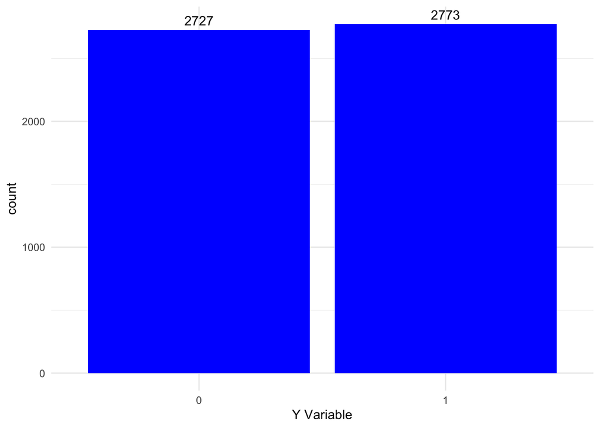

## Addressing Missingness

To remedy the missingness in the dataset, I created an empty list and filled it with all the missing values, turned it into a tibble, and omitted it from the dataset.

# Lasso Variable Selection

I used a lasso model for variable selection. After creating the model, I tidied it and used the `filter()` function to separate the variables for the fitted models.

# Recipe Building

## Kitchen Sink Recipe

I chose to use a kitchen sink recipe to evaluate the target variable using all of the predictor variables,

## Lasso Recipe

I created a separate recipe created from the variables I selected with the lasso model that I completed prior. I used `step_nzv()`, `step_normalize()`, `step_imput_mean()`, and `step_corr()` to complete this recipe.

# Resampling Technique

For resampling, I used a v-fold cross-validation technique with 10 folds and 5 repeats.

# Models Used

## Mars Model

The final model I used for my prediction was a mars model. I found this model to be the most proficient in achieving a high `roc_auc` score.

# Tuning Parameters

The tuning parameters I used for my mars model were `num_terms` and `prod_degree`.

# Model Results

The mars model was able to produce a `roc_auc` score above 0.583, which means it was the most successful model, which completed the original goal of the lab.

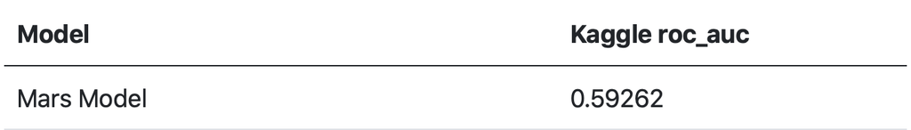

# Conclusion

In conclusion, I was able to produce a model with a `roc_auc` greater than 0.583. Although it took a few different tries with a few different models, The mars model ended up performing quite well and it was a great way for me to apply many of the concepts that we’ve been exploring in class.